# Course Project 1 for Data Science Specialization

## Loading and preprocessing the data

- **I will load the dplyr and lattice package for me to do all the explanatory analysis**

```r
library(lattice)
library(knitr)
library(dplyr)
```

- **Set the working directory and unzip the downloaded data**

```r
setwd("C://Users//LeoChaos//Desktop//Git//RepData_PeerAssessment1")
unzip("activity.zip")
actdata <- read.csv("activity.csv")
actdata <- tbl_df(actdata)
```

## What is mean total number of steps taken per day?

To tackle this problem, we can simply group our data and do the summary statistics.

1. **grouping data**

```r
grouped_data_bydate <- group_by(actdata, date)
```

2. **Calculate the total number of steps per day**

```r
sum1 <- summarise(grouped_data_bydate, sum = sum(steps,na.rm = TRUE))
res1 <- sum1$sum
```

3. **Draw the histogram and Calculate the mean and median of steps taken per day**

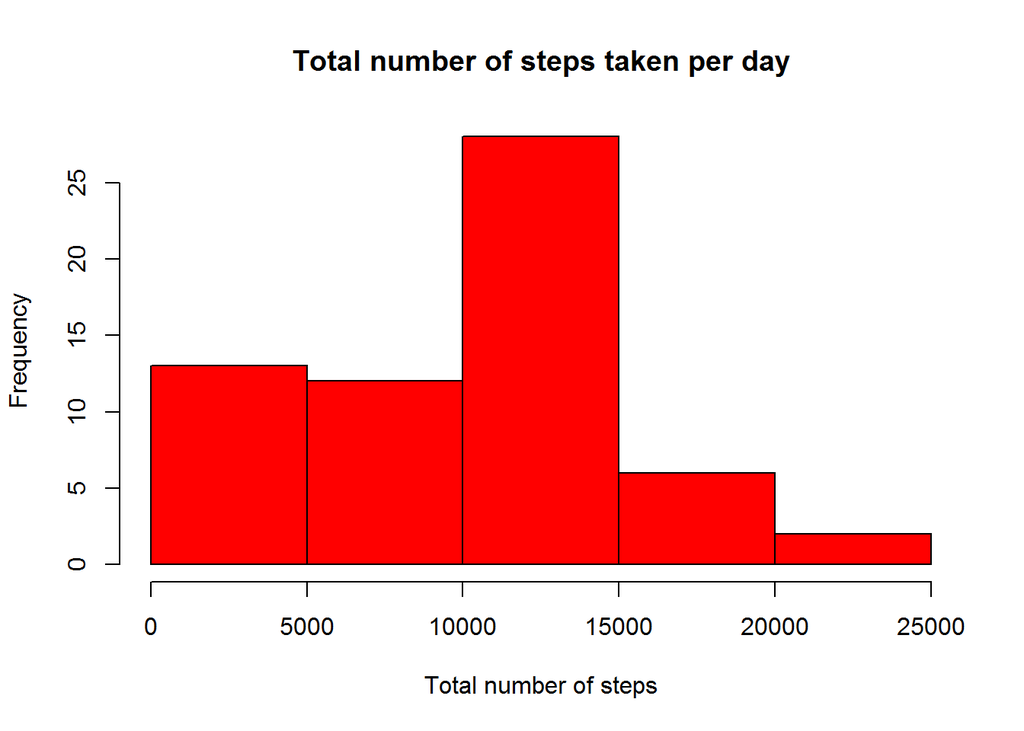

```r
hist(res1,col = "red",xlab = "Total number of steps", main = "Total number of steps taken per day" )
```

```r
dev.copy(png, "mean total number of steps taken per day.png")
dev.off()
step_mean <- mean(res1)
step_median <- median(res1)
```

*We can see the mean and median steps taken by this volunteer is 9354.2295082 and 10395.*

## What is the average daily activity pattern?

```r
grouped_data_byinterval <- group_by(actdata, interval)
```

2. **Second, we calculate the average steps taken at different time interval.**

```r
sum2 <- summarise(grouped_data_byinterval, mean = mean(steps,na.rm = TRUE))
res2 <- sum2$mean
```

3. **Next, we can draw a time series plot to see the average daily pattern**

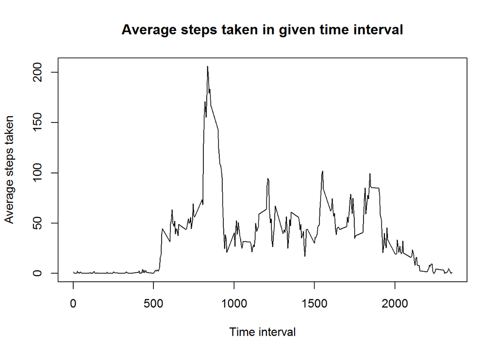

```r
plot(x = sum2$interval, y = res2, type = "l", xlab = "", ylab = "")
title(xlab = "Time interval", ylab = "Average steps taken",
      main = "Average steps taken in given time interval")
```

```r
dev.copy(png, "average number of steps taken across all days.png")
dev.off()
```

4. **Ultimately, let’s find his or her most active time**

```r
max_act_time <- sum2$interval[which.max(res2)]
```

*Hence, we can see that the volunteer’s most active time is around 8:35*

## Imputing missing values

1. **We first find the total missing values in our data**

```r
total_missing_values <- sum(is.na(actdata$steps))
percent <- mean(is.na(actdata$steps))
```

So there are 2304 NAs, which only constitute a small proportion (0.1311475) of our data

```r
grouped_data_bydate <- cbind(grouped_data_bydate, group_indices(grouped_data_bydate))
for(i in 1: length(grouped_data_bydate$steps)){
    if(is.na(grouped_data_bydate[i,1])){
        grouped_data_bydate[i,1] <- res1[grouped_data_bydate[i,4]]
    }
}
```

3. **So now, we have our filled new dataset**

```r
newdata <- ungroup(grouped_data_bydate)
```

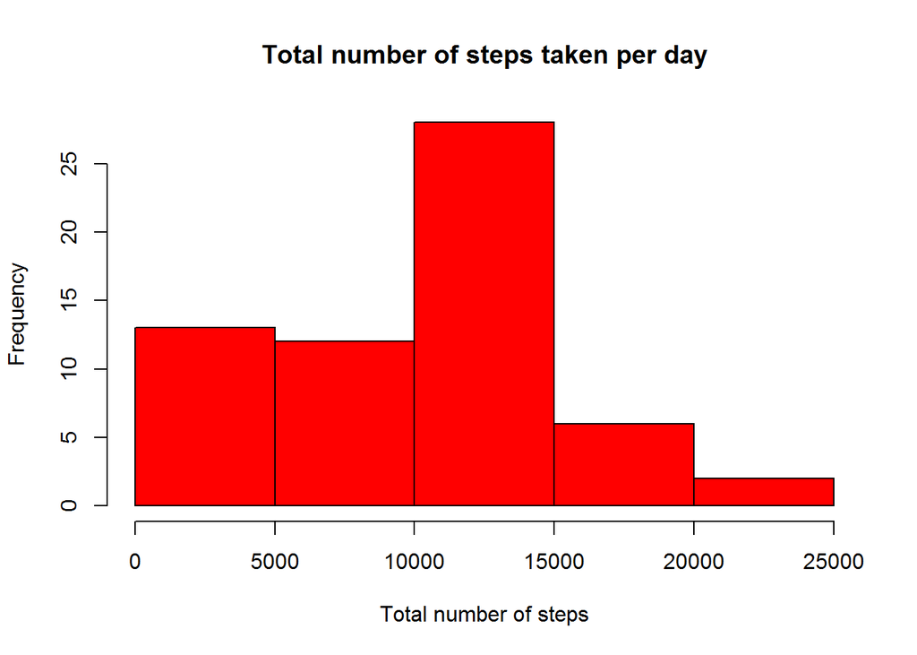

```r
sum3 <- summarise(newdata, sum = sum(steps,na.rm = TRUE))
res3 <- sum1$sum
hist(res3,col = "red",xlab = "Total number of steps", main = "Total number of steps taken per day" )
```

```r
dev.copy(png, "mean total number of steps taken per day(imputed).png")
dev.off()
steps_mean_imputed <- mean(res3)
steps_median_imputed <- median(res3)
```

# Are there differences in activity patterns between weekdays and weekends?

1. First, we should determine whether a given date is weekday or not

```r
date <- newdata$date
weekday <- weekdays(as.Date(date))
state <- character()
for (i in 1: length(weekday)){
    ##Sorry about the Chinese format...
    if(weekday[i] == "星期六" | weekday[i] ==  "星期日"){
        state[i] <- "weekend"
    }
    else {
        state[i] <- "weekday"
    }
}
state <- as.factor(state)
dat <- mutate(newdata, state = state)
```

2. Group new data by weekday or weekend and then compute the mean steps taken in weekday and weekend

```r
grouped_dat_byinterval <- group_by(dat, interval,state)
sum4 <- summarise(grouped_dat_byinterval, mean = mean(steps))
```

3. Visualize the result by lattice plotting system.

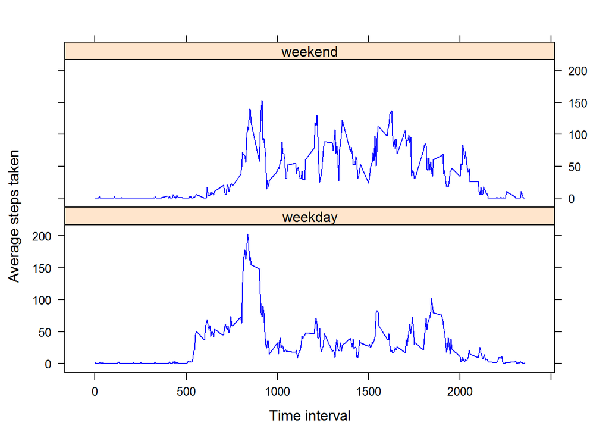

```r
xyplot(mean ~ interval | state, sum4, type = "l",col = "blue",
       xlab = "Time interval", ylab = "Average steps taken",
       layout = c(1,2))
```

```r
dev.copy(png, "5-minute interval and the average number of steps taken across all weekday days or weekend days.png")
dev.off()
```